# Marathon

```python
#https://www.kaggle.com/datasets/aiaiaidavid/the-big-dataset-of-ultra-marathon-running
```

```python
#Importing Libraries
import pandas as pd
import seaborn as sns
```

```python
df = pd.read_csv("TWO_CENTURIES_OF_UM_RACES.csv")
```

```python
df.head(10)
```

|  | Year of event | Event dates | Event name | Event distance/length | Event number of finishers | Athlete performance | Athlete club | Athlete country | Athlete year of birth | Athlete gender | Athlete age category | Athlete average speed | Athlete ID |
| --- | --- | --- | --- | --- | --- | --- | --- | --- | --- | --- | --- | --- | --- |
| 0 | 2018 | 06.01.2018 | Selva Costera (CHI) | 50km | 22 | 4:51:39 h | Tnfrc | CHI | 1978.0 | M | M35 | 10.286 | 0 |
| 1 | 2018 | 06.01.2018 | Selva Costera (CHI) | 50km | 22 | 5:15:45 h | Roberto Echeverría | CHI | 1981.0 | M | M35 | 9.501 | 1 |
| 2 | 2018 | 06.01.2018 | Selva Costera (CHI) | 50km | 22 | 5:16:44 h | Puro Trail Osorno | CHI | 1987.0 | M | M23 | 9.472 | 2 |
| 3 | 2018 | 06.01.2018 | Selva Costera (CHI) | 50km | 22 | 5:34:13 h | Columbia | ARG | 1976.0 | M | M40 | 8.976 | 3 |
| 4 | 2018 | 06.01.2018 | Selva Costera (CHI) | 50km | 22 | 5:54:14 h | Baguales Trail | CHI | 1992.0 | M | M23 | 8.469 | 4 |
| 5 | 2018 | 06.01.2018 | Selva Costera (CHI) | 50km | 22 | 6:25:01 h | NaN | ARG | 1974.0 | M | M40 | 7.792 | 5 |
| 6 | 2018 | 06.01.2018 | Selva Costera (CHI) | 50km | 22 | 6:28:00 h | Los Patagones | ARG | 1979.0 | F | W35 | 7.732 | 6 |
| 7 | 2018 | 06.01.2018 | Selva Costera (CHI) | 50km | 22 | 6:32:24 h | Reaktiva Chile | CHI | 1967.0 | F | W50 | 7.645 | 7 |
| 8 | 2018 | 06.01.2018 | Selva Costera (CHI) | 50km | 22 | 6:39:08 h | Puro Trail Osorno | CHI | 1985.0 | M | M23 | 7.516 | 8 |
| 9 | 2018 | 06.01.2018 | Selva Costera (CHI) | 50km | 22 | 6:45:11 h | Marlene Flores Team | CHI | 1976.0 | M | M40 | 7.404 | 9 |

```python
df.shape
```

```
(7461195, 13)
```

```python
df.dtypes
```

```
Year of event                  int64
Event dates                   object
Event name                    object
Event distance/length         object
Event number of finishers      int64
Athlete performance           object
Athlete club                  object
Athlete country               object
Athlete year of birth        float64
Athlete gender                object
Athlete age category          object
Athlete average speed         object
Athlete ID                     int64
dtype: object
```

# DATA CLEANING

summary of the steps taken: Filtered the DataFrame to include only races with distances of 50 km or 50 mi. Further filtered the DataFrame to include only races from the year 2022. Filtered the DataFrame to include only races in the USA by extracting the country from the event name. Removed unnecessary columns like Athlete club, Athlete country, Athlete year of birth, and Athlete age category. Cleaned the athlete's age and performance columns. Dropped rows with missing values. Converted data types to appropriate types. Renamed columns for better readability.

```python
#Only want USA Races 50k or 50 mi, 2020
#50 km and #50mi
```

```python
#Combining 50km and 50mi
df[df['Event distance/length'].isin(['50km','50mi'])]
```

|  | Year of event | Event dates | Event name | Event distance/length | Event number of finishers | Athlete performance | Athlete club | Athlete country | Athlete year of birth | Athlete gender | Athlete age category | Athlete average speed | Athlete ID |
| --- | --- | --- | --- | --- | --- | --- | --- | --- | --- | --- | --- | --- | --- |
| 0 | 2018 | 06.01.2018 | Selva Costera (CHI) | 50km | 22 | 4:51:39 h | Tnfrc | CHI | 1978.0 | M | M35 | 10.286 | 0 |
| 1 | 2018 | 06.01.2018 | Selva Costera (CHI) | 50km | 22 | 5:15:45 h | Roberto Echeverría | CHI | 1981.0 | M | M35 | 9.501 | 1 |
| 2 | 2018 | 06.01.2018 | Selva Costera (CHI) | 50km | 22 | 5:16:44 h | Puro Trail Osorno | CHI | 1987.0 | M | M23 | 9.472 | 2 |
| 3 | 2018 | 06.01.2018 | Selva Costera (CHI) | 50km | 22 | 5:34:13 h | Columbia | ARG | 1976.0 | M | M40 | 8.976 | 3 |
| 4 | 2018 | 06.01.2018 | Selva Costera (CHI) | 50km | 22 | 5:54:14 h | Baguales Trail | CHI | 1992.0 | M | M23 | 8.469 | 4 |
| ... | ... | ... | ... | ... | ... | ... | ... | ... | ... | ... | ... | ... | ... |
| 7461181 | 1995 | 07.01.1995 | Avalon Benefit 50-Mile Run (USA) | 50mi | 92 | 11:59:37 h | NaN | USA | 1941.0 | M | M50 | 6709.0 | 1045603 |
| 7461182 | 1995 | 07.01.1995 | Avalon Benefit 50-Mile Run (USA) | 50mi | 92 | 12:01:41 h | NaN | USA | 1932.0 | M | M60 | 6690.0 | 1070463 |
| 7461183 | 1995 | 07.01.1995 | Avalon Benefit 50-Mile Run (USA) | 50mi | 92 | 12:03:26 h | NaN | USA | 1934.0 | F | W60 | 6674.0 | 416139 |
| 7461184 | 1995 | 07.01.1995 | Avalon Benefit 50-Mile Run (USA) | 50mi | 92 | 12:03:26 h | NaN | USA | 1951.0 | F | W40 | 6674.0 | 1098098 |
| 7461185 | 1995 | 07.01.1995 | Avalon Benefit 50-Mile Run (USA) | 50mi | 92 | 12:05:59 h | NaN | USA | 1947.0 | F | W45 | 6650.0 | 1626367 |

1874790 rows × 13 columns

```python
df[(df['Event distance/length'].isin(['50km','50mi'])) & (df['Year of event'] == 2022) ]
```

|  | Year of event | Event dates | Event name | Event distance/length | Event number of finishers | Athlete performance | Athlete club | Athlete country | Athlete year of birth | Athlete gender | Athlete age category | Athlete average speed | Athlete ID |
| --- | --- | --- | --- | --- | --- | --- | --- | --- | --- | --- | --- | --- | --- |
| 3138208 | 2022 | 12.03.2022 | Bel Monte 50 Mile Endurance Run (USA) | 50mi | 49 | 7:53:36 h | *Boston, MA | USA | 1994.0 | M | M23 | 10.194 | 839364 |
| 3138209 | 2022 | 12.03.2022 | Bel Monte 50 Mile Endurance Run (USA) | 50mi | 49 | 8:14:24 h | *Charlotte, NC | USA | 1990.0 | M | M23 | 9.765 | 366598 |
| 3138210 | 2022 | 12.03.2022 | Bel Monte 50 Mile Endurance Run (USA) | 50mi | 49 | 8:19:16 h | *Kannapolis, NC | USA | 1979.0 | M | M40 | 9.67 | 553476 |
| 3138211 | 2022 | 12.03.2022 | Bel Monte 50 Mile Endurance Run (USA) | 50mi | 49 | 8:23:49 h | *Raleigh, NC | USA | 1994.0 | M | M23 | 9.583 | 807555 |
| 3138212 | 2022 | 12.03.2022 | Bel Monte 50 Mile Endurance Run (USA) | 50mi | 49 | 8:41:37 h | *Washington, DC | USA | 1997.0 | M | M23 | 9.256 | 947348 |
| ... | ... | ... | ... | ... | ... | ... | ... | ... | ... | ... | ... | ... | ... |
| 3609801 | 2022 | 16.10.2022 | Tussey Mountainback 50 Miler (USA) | 50mi | 35 | 11:16:08 h | *Peachtree City, GA | USA | 1968.0 | M | M50 | 7.141 | 1044739 |
| 3609802 | 2022 | 16.10.2022 | Tussey Mountainback 50 Miler (USA) | 50mi | 35 | 11:27:05 h | *Newport, PA | USA | 1959.0 | M | M60 | 7.027 | 50971 |
| 3609803 | 2022 | 16.10.2022 | Tussey Mountainback 50 Miler (USA) | 50mi | 35 | 11:46:34 h | *Flemington, NJ | USA | 1955.0 | F | W65 | 6.833 | 73152 |
| 3609804 | 2022 | 16.10.2022 | Tussey Mountainback 50 Miler (USA) | 50mi | 35 | 11:55:29 h | *Arlington, VA | USA | 1965.0 | M | M55 | 6.748 | 970133 |
| 3609805 | 2022 | 16.10.2022 | Tussey Mountainback 50 Miler (USA) | 50mi | 35 | 12:14:15 h | *Johnstown, PA | USA | 1981.0 | F | W40 | 6.575 | 723380 |

111250 rows × 13 columns

```python
df[df['Event name'].str.split('(').str.get(1).str.split(')').str.get(0) == 'USA']
```

|  | Year of event | Event dates | Event name | Event distance/length | Event number of finishers | Athlete performance | Athlete club | Athlete country | Athlete year of birth | Athlete gender | Athlete age category | Athlete average speed | Athlete ID |
| --- | --- | --- | --- | --- | --- | --- | --- | --- | --- | --- | --- | --- | --- |
| 55 | 2018 | 06.01.2018 | Yankee Springs 50 Mile Winter Challenge (USA) | 50mi | 9 | 9:53:05 h | *Middleville, MI | USA | 1983.0 | M | M23 | 8.141 | 55 |
| 56 | 2018 | 06.01.2018 | Yankee Springs 50 Mile Winter Challenge (USA) | 50mi | 9 | 11:09:35 h | *Waterloo, ON | CAN | 1977.0 | F | W40 | 7.211 | 56 |
| 57 | 2018 | 06.01.2018 | Yankee Springs 50 Mile Winter Challenge (USA) | 50mi | 9 | 11:33:00 h | *Kitchener, ON | CAN | 1976.0 | M | M40 | 6.967 | 57 |
| 58 | 2018 | 06.01.2018 | Yankee Springs 50 Mile Winter Challenge (USA) | 50mi | 9 | 11:38:17 h | *Utica, MI | USA | 1986.0 | M | M23 | 6.914 | 58 |
| 59 | 2018 | 06.01.2018 | Yankee Springs 50 Mile Winter Challenge (USA) | 50mi | 9 | 11:56:35 h | *Grass Lake, MI | USA | 1988.0 | M | M23 | 6.738 | 59 |
| ... | ... | ... | ... | ... | ... | ... | ... | ... | ... | ... | ... | ... | ... |
| 7461181 | 1995 | 07.01.1995 | Avalon Benefit 50-Mile Run (USA) | 50mi | 92 | 11:59:37 h | NaN | USA | 1941.0 | M | M50 | 6709.0 | 1045603 |
| 7461182 | 1995 | 07.01.1995 | Avalon Benefit 50-Mile Run (USA) | 50mi | 92 | 12:01:41 h | NaN | USA | 1932.0 | M | M60 | 6690.0 | 1070463 |
| 7461183 | 1995 | 07.01.1995 | Avalon Benefit 50-Mile Run (USA) | 50mi | 92 | 12:03:26 h | NaN | USA | 1934.0 | F | W60 | 6674.0 | 416139 |
| 7461184 | 1995 | 07.01.1995 | Avalon Benefit 50-Mile Run (USA) | 50mi | 92 | 12:03:26 h | NaN | USA | 1951.0 | F | W40 | 6674.0 | 1098098 |
| 7461185 | 1995 | 07.01.1995 | Avalon Benefit 50-Mile Run (USA) | 50mi | 92 | 12:05:59 h | NaN | USA | 1947.0 | F | W45 | 6650.0 | 1626367 |

1398540 rows × 13 columns

```python
#Combining all the Filters:
```

```python
df[(df['Event distance/length'].isin(['50km','50mi'])) & (df['Year of event'] == 2022) &  (df['Event name'].str.split('(').str.get(1).str.split(')').str.get(0) == 'USA')]
```

|  | Year of event | Event dates | Event name | Event distance/length | Event number of finishers | Athlete performance | Athlete club | Athlete country | Athlete year of birth | Athlete gender | Athlete age category | Athlete average speed | Athlete ID |
| --- | --- | --- | --- | --- | --- | --- | --- | --- | --- | --- | --- | --- | --- |
| 3138208 | 2022 | 12.03.2022 | Bel Monte 50 Mile Endurance Run (USA) | 50mi | 49 | 7:53:36 h | *Boston, MA | USA | 1994.0 | M | M23 | 10.194 | 839364 |
| 3138209 | 2022 | 12.03.2022 | Bel Monte 50 Mile Endurance Run (USA) | 50mi | 49 | 8:14:24 h | *Charlotte, NC | USA | 1990.0 | M | M23 | 9.765 | 366598 |
| 3138210 | 2022 | 12.03.2022 | Bel Monte 50 Mile Endurance Run (USA) | 50mi | 49 | 8:19:16 h | *Kannapolis, NC | USA | 1979.0 | M | M40 | 9.67 | 553476 |
| 3138211 | 2022 | 12.03.2022 | Bel Monte 50 Mile Endurance Run (USA) | 50mi | 49 | 8:23:49 h | *Raleigh, NC | USA | 1994.0 | M | M23 | 9.583 | 807555 |
| 3138212 | 2022 | 12.03.2022 | Bel Monte 50 Mile Endurance Run (USA) | 50mi | 49 | 8:41:37 h | *Washington, DC | USA | 1997.0 | M | M23 | 9.256 | 947348 |
| ... | ... | ... | ... | ... | ... | ... | ... | ... | ... | ... | ... | ... | ... |
| 3609801 | 2022 | 16.10.2022 | Tussey Mountainback 50 Miler (USA) | 50mi | 35 | 11:16:08 h | *Peachtree City, GA | USA | 1968.0 | M | M50 | 7.141 | 1044739 |
| 3609802 | 2022 | 16.10.2022 | Tussey Mountainback 50 Miler (USA) | 50mi | 35 | 11:27:05 h | *Newport, PA | USA | 1959.0 | M | M60 | 7.027 | 50971 |
| 3609803 | 2022 | 16.10.2022 | Tussey Mountainback 50 Miler (USA) | 50mi | 35 | 11:46:34 h | *Flemington, NJ | USA | 1955.0 | F | W65 | 6.833 | 73152 |
| 3609804 | 2022 | 16.10.2022 | Tussey Mountainback 50 Miler (USA) | 50mi | 35 | 11:55:29 h | *Arlington, VA | USA | 1965.0 | M | M55 | 6.748 | 970133 |
| 3609805 | 2022 | 16.10.2022 | Tussey Mountainback 50 Miler (USA) | 50mi | 35 | 12:14:15 h | *Johnstown, PA | USA | 1981.0 | F | W40 | 6.575 | 723380 |

58600 rows × 13 columns

```python
df_filtered = df[(df['Event distance/length'].isin(['50km','50mi'])) & (df['Year of event'] == 2022) &  (df['Event name'].str.split('(').str.get(1).str.split(')').str.get(0) == 'USA')]
```

```python
df_filtered.head()
```

|  | Year of event | Event dates | Event name | Event distance/length | Event number of finishers | Athlete performance | Athlete club | Athlete country | Athlete year of birth | Athlete gender | Athlete age category | Athlete average speed | Athlete ID |
| --- | --- | --- | --- | --- | --- | --- | --- | --- | --- | --- | --- | --- | --- |
| 3138208 | 2022 | 12.03.2022 | Bel Monte 50 Mile Endurance Run (USA) | 50mi | 49 | 7:53:36 h | *Boston, MA | USA | 1994.0 | M | M23 | 10.194 | 839364 |
| 3138209 | 2022 | 12.03.2022 | Bel Monte 50 Mile Endurance Run (USA) | 50mi | 49 | 8:14:24 h | *Charlotte, NC | USA | 1990.0 | M | M23 | 9.765 | 366598 |
| 3138210 | 2022 | 12.03.2022 | Bel Monte 50 Mile Endurance Run (USA) | 50mi | 49 | 8:19:16 h | *Kannapolis, NC | USA | 1979.0 | M | M40 | 9.67 | 553476 |
| 3138211 | 2022 | 12.03.2022 | Bel Monte 50 Mile Endurance Run (USA) | 50mi | 49 | 8:23:49 h | *Raleigh, NC | USA | 1994.0 | M | M23 | 9.583 | 807555 |
| 3138212 | 2022 | 12.03.2022 | Bel Monte 50 Mile Endurance Run (USA) | 50mi | 49 | 8:41:37 h | *Washington, DC | USA | 1997.0 | M | M23 | 9.256 | 947348 |

```python
df_filtered.shape
```

```
(58600, 13)
```

```python
#Removing USA from event name
df_filtered['Event name'] = df_filtered['Event name'].str.split('(').str.get(0)
```

```python
df_filtered.head()
```

|  | Year of event | Event dates | Event name | Event distance/length | Event number of finishers | Athlete performance | Athlete club | Athlete country | Athlete year of birth | Athlete gender | Athlete age category | Athlete average speed | Athlete ID |
| --- | --- | --- | --- | --- | --- | --- | --- | --- | --- | --- | --- | --- | --- |
| 3138208 | 2022 | 12.03.2022 | Bel Monte 50 Mile Endurance Run | 50mi | 49 | 7:53:36 h | *Boston, MA | USA | 1994.0 | M | M23 | 10.194 | 839364 |
| 3138209 | 2022 | 12.03.2022 | Bel Monte 50 Mile Endurance Run | 50mi | 49 | 8:14:24 h | *Charlotte, NC | USA | 1990.0 | M | M23 | 9.765 | 366598 |
| 3138210 | 2022 | 12.03.2022 | Bel Monte 50 Mile Endurance Run | 50mi | 49 | 8:19:16 h | *Kannapolis, NC | USA | 1979.0 | M | M40 | 9.67 | 553476 |
| 3138211 | 2022 | 12.03.2022 | Bel Monte 50 Mile Endurance Run | 50mi | 49 | 8:23:49 h | *Raleigh, NC | USA | 1994.0 | M | M23 | 9.583 | 807555 |
| 3138212 | 2022 | 12.03.2022 | Bel Monte 50 Mile Endurance Run | 50mi | 49 | 8:41:37 h | *Washington, DC | USA | 1997.0 | M | M23 | 9.256 | 947348 |

```python
    #Cleaning Athelete Age
    df_filtered['athelete_age'] = 2020 - df_filtered['Athlete year of birth']
```

```python
#Removing h from athelete Performances
df_filtered['Athlete performance'] = df_filtered['Athlete performance'].str.replace('h', '')

# Display the modified column
print(df_filtered['Athlete performance'])
```

```
3138208     7:53:36
3138209     8:14:24
3138210     8:19:16
3138211     8:23:49
3138212     8:41:37
             ...
3609801    11:16:08
3609802    11:27:05
3609803    11:46:34
3609804    11:55:29
3609805    12:14:15
Name: Athlete performance, Length: 58600, dtype: object
```

```python
df_filtered.head()
```

|  | Year of event | Event dates | Event name | Event distance/length | Event number of finishers | Athlete performance | Athlete club | Athlete country | Athlete year of birth | Athlete gender | Athlete age category | Athlete average speed | Athlete ID | athelete_age |
| --- | --- | --- | --- | --- | --- | --- | --- | --- | --- | --- | --- | --- | --- | --- |
| 3138208 | 2022 | 12.03.2022 | Bel Monte 50 Mile Endurance Run | 50mi | 49 | 7:53:36 | *Boston, MA | USA | 1994.0 | M | M23 | 10.194 | 839364 | 26.0 |
| 3138209 | 2022 | 12.03.2022 | Bel Monte 50 Mile Endurance Run | 50mi | 49 | 8:14:24 | *Charlotte, NC | USA | 1990.0 | M | M23 | 9.765 | 366598 | 30.0 |
| 3138210 | 2022 | 12.03.2022 | Bel Monte 50 Mile Endurance Run | 50mi | 49 | 8:19:16 | *Kannapolis, NC | USA | 1979.0 | M | M40 | 9.67 | 553476 | 41.0 |
| 3138211 | 2022 | 12.03.2022 | Bel Monte 50 Mile Endurance Run | 50mi | 49 | 8:23:49 | *Raleigh, NC | USA | 1994.0 | M | M23 | 9.583 | 807555 | 26.0 |
| 3138212 | 2022 | 12.03.2022 | Bel Monte 50 Mile Endurance Run | 50mi | 49 | 8:41:37 | *Washington, DC | USA | 1997.0 | M | M23 | 9.256 | 947348 | 23.0 |

```python
#Dropping unwanted coloumns : AThlete Club, Althlete Country, Athlete Year of birth, Athlete age category
df_filtered = df_filtered.drop(['Athlete club','Athlete country','Athlete year of birth','Athlete age category'],axis = 1)
```

```python
df_filtered.head()
```

|  | Year of event | Event dates | Event name | Event distance/length | Event number of finishers | Athlete performance | Athlete gender | Athlete average speed | Athlete ID | athelete_age |
| --- | --- | --- | --- | --- | --- | --- | --- | --- | --- | --- |
| 3138208 | 2022 | 12.03.2022 | Bel Monte 50 Mile Endurance Run | 50mi | 49 | 7:53:36 | M | 10.194 | 839364 | 26.0 |
| 3138209 | 2022 | 12.03.2022 | Bel Monte 50 Mile Endurance Run | 50mi | 49 | 8:14:24 | M | 9.765 | 366598 | 30.0 |
| 3138210 | 2022 | 12.03.2022 | Bel Monte 50 Mile Endurance Run | 50mi | 49 | 8:19:16 | M | 9.67 | 553476 | 41.0 |
| 3138211 | 2022 | 12.03.2022 | Bel Monte 50 Mile Endurance Run | 50mi | 49 | 8:23:49 | M | 9.583 | 807555 | 26.0 |
| 3138212 | 2022 | 12.03.2022 | Bel Monte 50 Mile Endurance Run | 50mi | 49 | 8:41:37 | M | 9.256 | 947348 | 23.0 |

```python
#Removing Null Values
df_filtered.isna().sum()
```

```
Year of event                   0
Event dates                     0
Event name                      0
Event distance/length           0
Event number of finishers       0
Athlete performance             0
Athlete gender                  0
Athlete average speed           0
Athlete ID                      0
athelete_age                 1788
dtype: int64
```

```python
df_filtered[df_filtered['athelete_age'].isna()==1]
```

|  | Year of event | Event dates | Event name | Event distance/length | Event number of finishers | Athlete performance | Athlete gender | Athlete average speed | Athlete ID | athelete_age |
| --- | --- | --- | --- | --- | --- | --- | --- | --- | --- | --- |
| 3139609 | 2022 | 12.03.2022 | Antelope Canyon 50 Mile | 50mi | 251 | 9:42:19 | F | 8.291 | 947523 | NaN |
| 3139615 | 2022 | 12.03.2022 | Antelope Canyon 50 Mile | 50mi | 251 | 10:06:45 | M | 7.957 | 947524 | NaN |
| 3139616 | 2022 | 12.03.2022 | Antelope Canyon 50 Mile | 50mi | 251 | 10:12:39 | M | 7.881 | 708185 | NaN |
| 3139642 | 2022 | 12.03.2022 | Antelope Canyon 50 Mile | 50mi | 251 | 11:05:36 | M | 7.254 | 947527 | NaN |
| 3139655 | 2022 | 12.03.2022 | Antelope Canyon 50 Mile | 50mi | 251 | 11:23:41 | M | 7.062 | 947528 | NaN |
| ... | ... | ... | ... | ... | ... | ... | ... | ... | ... | ... |
| 3601761 | 2022 | 22.10.2022 | Lake Hodges Trail Fest 50K | 50km | 116 | 7:20:19 | M | 6.813 | 74573 | NaN |
| 3601768 | 2022 | 22.10.2022 | Lake Hodges Trail Fest 50K | 50km | 116 | 7:30:35 | F | 6.658 | 1043495 | NaN |
| 3601771 | 2022 | 22.10.2022 | Lake Hodges Trail Fest 50K | 50km | 116 | 7:50:50 | M | 6.372 | 1043497 | NaN |
| 3601774 | 2022 | 22.10.2022 | Lake Hodges Trail Fest 50K | 50km | 116 | 8:00:28 | M | 6.244 | 1043498 | NaN |
| 3601776 | 2022 | 22.10.2022 | Lake Hodges Trail Fest 50K | 50km | 116 | 8:17:40 | M | 6.028 | 816612 | NaN |

1788 rows × 10 columns

```python
df_filtered = df_filtered.dropna()
```

```python
df_filtered.shape
```

```
(56812, 10)
```

```python
#Checking duplicate values
df_filtered[df_filtered.duplicated()== True]
```

|  | Year of event | Event dates | Event name | Event distance/length | Event number of finishers | Athlete performance | Athlete gender | Athlete average speed | Athlete ID | athelete_age |
| --- | --- | --- | --- | --- | --- | --- | --- | --- | --- | --- |

```python
#Reset Index
df_filtered.reset_index(drop = True)
```

|  | Year of event | Event dates | Event name | Event distance/length | Event number of finishers | Athlete performance | Athlete gender | Athlete average speed | Athlete ID | athelete_age |
| --- | --- | --- | --- | --- | --- | --- | --- | --- | --- | --- |
| 0 | 2022 | 12.03.2022 | Bel Monte 50 Mile Endurance Run | 50mi | 49 | 7:53:36 | M | 10.194 | 839364 | 26.0 |
| 1 | 2022 | 12.03.2022 | Bel Monte 50 Mile Endurance Run | 50mi | 49 | 8:14:24 | M | 9.765 | 366598 | 30.0 |
| 2 | 2022 | 12.03.2022 | Bel Monte 50 Mile Endurance Run | 50mi | 49 | 8:19:16 | M | 9.67 | 553476 | 41.0 |
| 3 | 2022 | 12.03.2022 | Bel Monte 50 Mile Endurance Run | 50mi | 49 | 8:23:49 | M | 9.583 | 807555 | 26.0 |
| 4 | 2022 | 12.03.2022 | Bel Monte 50 Mile Endurance Run | 50mi | 49 | 8:41:37 | M | 9.256 | 947348 | 23.0 |
| ... | ... | ... | ... | ... | ... | ... | ... | ... | ... | ... |
| 56807 | 2022 | 16.10.2022 | Tussey Mountainback 50 Miler | 50mi | 35 | 11:16:08 | M | 7.141 | 1044739 | 52.0 |
| 56808 | 2022 | 16.10.2022 | Tussey Mountainback 50 Miler | 50mi | 35 | 11:27:05 | M | 7.027 | 50971 | 61.0 |
| 56809 | 2022 | 16.10.2022 | Tussey Mountainback 50 Miler | 50mi | 35 | 11:46:34 | F | 6.833 | 73152 | 65.0 |
| 56810 | 2022 | 16.10.2022 | Tussey Mountainback 50 Miler | 50mi | 35 | 11:55:29 | M | 6.748 | 970133 | 55.0 |
| 56811 | 2022 | 16.10.2022 | Tussey Mountainback 50 Miler | 50mi | 35 | 12:14:15 | F | 6.575 | 723380 | 39.0 |

56812 rows × 10 columns

```python
#Fixing Types
df_filtered.dtypes
```

```
Year of event                  int64
Event dates                   object
Event name                    object
Event distance/length         object
Event number of finishers      int64
Athlete performance           object
Athlete gender                object
Athlete average speed         object
Athlete ID                     int64
athelete_age                 float64
dtype: object
```

```python
df_filtered['athelete_age'] = df_filtered['athelete_age'].astype(int)
df_filtered['Athlete average speed'] = df_filtered['Athlete average speed'].astype(float)
```

```python
df_filtered.head()
```

|  | Year of event | Event dates | Event name | Event distance/length | Event number of finishers | Athlete performance | Athlete gender | Athlete average speed | Athlete ID | athelete_age |
| --- | --- | --- | --- | --- | --- | --- | --- | --- | --- | --- |
| 3138208 | 2022 | 12.03.2022 | Bel Monte 50 Mile Endurance Run | 50mi | 49 | 7:53:36 | M | 10.194 | 839364 | 26 |
| 3138209 | 2022 | 12.03.2022 | Bel Monte 50 Mile Endurance Run | 50mi | 49 | 8:14:24 | M | 9.765 | 366598 | 30 |
| 3138210 | 2022 | 12.03.2022 | Bel Monte 50 Mile Endurance Run | 50mi | 49 | 8:19:16 | M | 9.670 | 553476 | 41 |
| 3138211 | 2022 | 12.03.2022 | Bel Monte 50 Mile Endurance Run | 50mi | 49 | 8:23:49 | M | 9.583 | 807555 | 26 |
| 3138212 | 2022 | 12.03.2022 | Bel Monte 50 Mile Endurance Run | 50mi | 49 | 8:41:37 | M | 9.256 | 947348 | 23 |

```python
#Renaming Coloumn
df_filtered = df_filtered.rename(columns = {'Year of event': 'year',
                                     'Event dates': 'race_day',
                                     'Event name': 'race_name',
                                     'Event distance/length': 'race_length',
                                     'Event number of finishers': 'race_number_of_finishes',
                                     'Athlete performance': 'athlete_performance',
                                     'Athlete gender': 'athlete_gender',
                                     'Athlete average speed': 'athlete_average_speed',
                                     'Athlete ID': 'athlete_id'
                                    })
```

```python
df_filtered.head()
```

|  | year | race_day | race_name | race_length | race_number_of_finishes | athlete_performance | athlete_gender | athlete_average_speed | athlete_id | athelete_age |
| --- | --- | --- | --- | --- | --- | --- | --- | --- | --- | --- |
| 3138208 | 2022 | 12.03.2022 | Bel Monte 50 Mile Endurance Run | 50mi | 49 | 7:53:36 | M | 10.194 | 839364 | 26 |
| 3138209 | 2022 | 12.03.2022 | Bel Monte 50 Mile Endurance Run | 50mi | 49 | 8:14:24 | M | 9.765 | 366598 | 30 |
| 3138210 | 2022 | 12.03.2022 | Bel Monte 50 Mile Endurance Run | 50mi | 49 | 8:19:16 | M | 9.670 | 553476 | 41 |
| 3138211 | 2022 | 12.03.2022 | Bel Monte 50 Mile Endurance Run | 50mi | 49 | 8:23:49 | M | 9.583 | 807555 | 26 |
| 3138212 | 2022 | 12.03.2022 | Bel Monte 50 Mile Endurance Run | 50mi | 49 | 8:41:37 | M | 9.256 | 947348 | 23 |

```python
#Reordering Columns
df_reorder = df_filtered[['race_day', 'race_name', 'race_length', 'race_number_of_finishes', 'athlete_id', 'athlete_gender', 'athelete_age', 'athlete_performance', 'athlete_average_speed'
]]
```

```python
df_reorder.head()
```

|  | race_day | race_name | race_length | race_number_of_finishes | athlete_id | athlete_gender | athelete_age | athlete_performance | athlete_average_speed |
| --- | --- | --- | --- | --- | --- | --- | --- | --- | --- |
| 3138208 | 12.03.2022 | Bel Monte 50 Mile Endurance Run | 50mi | 49 | 839364 | M | 26 | 7:53:36 | 10.194 |
| 3138209 | 12.03.2022 | Bel Monte 50 Mile Endurance Run | 50mi | 49 | 366598 | M | 30 | 8:14:24 | 9.765 |
| 3138210 | 12.03.2022 | Bel Monte 50 Mile Endurance Run | 50mi | 49 | 553476 | M | 41 | 8:19:16 | 9.670 |
| 3138211 | 12.03.2022 | Bel Monte 50 Mile Endurance Run | 50mi | 49 | 807555 | M | 26 | 8:23:49 | 9.583 |
| 3138212 | 12.03.2022 | Bel Monte 50 Mile Endurance Run | 50mi | 49 | 947348 | M | 23 | 8:41:37 | 9.256 |

# DATA VISUALIZATION

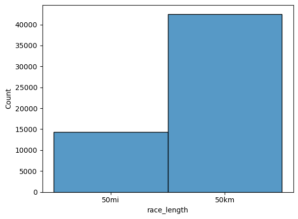

```python
sns.histplot(df_reorder['race_length'])
```

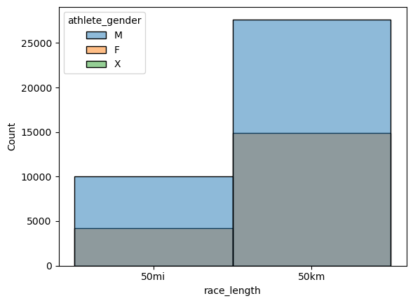

```python
sns.histplot(df_reorder, x= 'race_length', hue = 'athlete_gender')
```

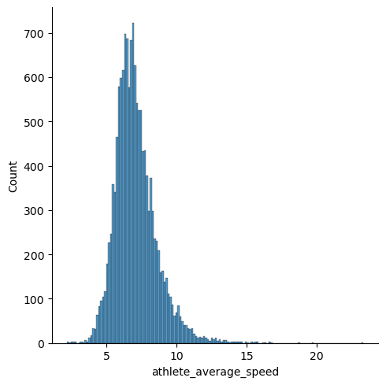

```python
sns.displot(df_reorder[df_reorder['race_length'] =='50mi']['athlete_average_speed'])
```

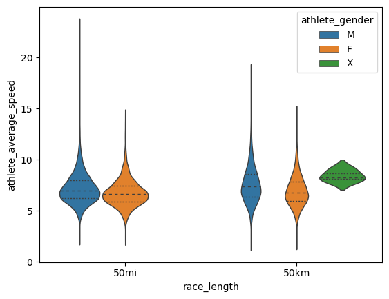

```python
sns.violinplot(data=df_reorder, x='race_length', y='athlete_average_speed', hue='athlete_gender', inner='quart', linewidth=1)
```

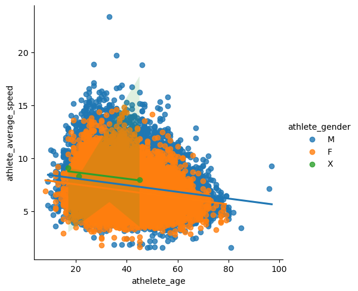

```python
sns.lmplot(data= df_reorder, x= 'athelete_age', y = 'athlete_average_speed',hue = 'athlete_gender')
```

## Questions to Answer from Data:

```python
#Difference in speed for the 50km , 50mi male to female
df_reorder.groupby(['race_length','athlete_gender'])['athlete_average_speed'].mean()
```

```
race_length  athlete_gender
50km         F                 6.966948
             M                 7.562757
             X                 8.444000
50mi         F                 6.779096
             M                 7.218046
Name: athlete_average_speed, dtype: float64
```

```python
#What age groups are the best in the 50cm Race(20 + race min)
df_reorder.query('race_length == "50mi"').groupby('athelete_age')['athlete_average_speed'].agg(['mean', 'count']).sort_values('mean', ascending=False).query('count > 19')
```

| athelete_age | mean | count |
| --- | --- | --- |
| 17 | 7.781079 | 38 |
| 24 | 7.750676 | 262 |
| 18 | 7.633224 | 67 |
| 30 | 7.560600 | 418 |
| 22 | 7.526565 | 186 |
| 23 | 7.477597 | 206 |
| 26 | 7.428883 | 325 |
| 29 | 7.424462 | 394 |
| 25 | 7.418414 | 256 |
| 19 | 7.400543 | 92 |
| 20 | 7.391286 | 112 |
| 32 | 7.388895 | 457 |
| 27 | 7.352136 | 367 |
| 28 | 7.347627 | 367 |
| 35 | 7.345280 | 517 |
| 21 | 7.306007 | 152 |
| 36 | 7.257154 | 507 |
| 33 | 7.220825 | 435 |
| 34 | 7.211051 | 469 |
| 37 | 7.184612 | 529 |
| 38 | 7.174552 | 525 |
| 41 | 7.111561 | 467 |
| 42 | 7.096572 | 467 |
| 31 | 7.087146 | 417 |
| 47 | 7.053153 | 339 |
| 40 | 6.996457 | 541 |
| 44 | 6.989770 | 435 |
| 16 | 6.982250 | 20 |
| 39 | 6.979280 | 557 |
| 55 | 6.955940 | 166 |
| 43 | 6.923007 | 436 |
| 46 | 6.884575 | 369 |
| 51 | 6.871323 | 294 |
| 45 | 6.853639 | 404 |
| 49 | 6.791651 | 307 |
| 56 | 6.761993 | 139 |
| 52 | 6.761831 | 255 |
| 50 | 6.739696 | 283 |
| 48 | 6.724938 | 384 |
| 59 | 6.656684 | 95 |
| 57 | 6.649380 | 150 |
| 60 | 6.645245 | 98 |
| 54 | 6.619654 | 182 |
| 53 | 6.590199 | 211 |
| 58 | 6.514132 | 144 |
| 61 | 6.499551 | 89 |
| 62 | 6.263042 | 71 |
| 64 | 6.120250 | 40 |
| 65 | 6.089679 | 28 |
| 63 | 5.990196 | 51 |
| 67 | 5.976714 | 28 |
| 66 | 5.758423 | 26 |

```python
#What age groups are the worst in the 50cm Race(20 + race min)(show 20)
df_reorder.query('race_length == "50mi"').groupby('athelete_age')['athlete_average_speed'].agg(['mean', 'count']).sort_values('mean', ascending=True).query('count > 9')
```

| athelete_age | mean | count |
| --- | --- | --- |
| 72 | 5.426800 | 10 |
| 71 | 5.486500 | 16 |
| 66 | 5.758423 | 26 |
| 68 | 5.958667 | 18 |
| 67 | 5.976714 | 28 |
| 63 | 5.990196 | 51 |
| 69 | 6.078100 | 10 |
| 65 | 6.089679 | 28 |
| 64 | 6.120250 | 40 |
| 70 | 6.129071 | 14 |
| 62 | 6.263042 | 71 |
| 61 | 6.499551 | 89 |
| 58 | 6.514132 | 144 |
| 53 | 6.590199 | 211 |
| 54 | 6.619654 | 182 |
| 60 | 6.645245 | 98 |
| 57 | 6.649380 | 150 |
| 59 | 6.656684 | 95 |
| 48 | 6.724938 | 384 |
| 50 | 6.739696 | 283 |
| 52 | 6.761831 | 255 |
| 56 | 6.761993 | 139 |
| 49 | 6.791651 | 307 |
| 45 | 6.853639 | 404 |
| 51 | 6.871323 | 294 |
| 46 | 6.884575 | 369 |
| 43 | 6.923007 | 436 |
| 55 | 6.955940 | 166 |
| 39 | 6.979280 | 557 |
| 16 | 6.982250 | 20 |
| 44 | 6.989770 | 435 |
| 40 | 6.996457 | 541 |
| 47 | 7.053153 | 339 |
| 31 | 7.087146 | 417 |
| 42 | 7.096572 | 467 |
| 15 | 7.107600 | 10 |
| 41 | 7.111561 | 467 |
| 38 | 7.174552 | 525 |
| 37 | 7.184612 | 529 |
| 34 | 7.211051 | 469 |
| 33 | 7.220825 | 435 |
| 36 | 7.257154 | 507 |
| 21 | 7.306007 | 152 |
| 35 | 7.345280 | 517 |
| 28 | 7.347627 | 367 |
| 27 | 7.352136 | 367 |
| 32 | 7.388895 | 457 |
| 20 | 7.391286 | 112 |
| 19 | 7.400543 | 92 |
| 25 | 7.418414 | 256 |
| 29 | 7.424462 | 394 |
| 26 | 7.428883 | 325 |
| 23 | 7.477597 | 206 |
| 22 | 7.526565 | 186 |
| 30 | 7.560600 | 418 |
| 18 | 7.633224 | 67 |
| 24 | 7.750676 | 262 |
| 17 | 7.781079 | 38 |

```python
#Seasons for data -> Slower in summer  than winter?
#spring 3-5
#summer 6-8
#fall 9-11
#winter 12-2
df_reorder['race_month']= df_reorder['race_day'].str.split('.').str.get(1).astype(int)
```

```python
df_reorder['race_season'] = df_reorder['race_month'].apply(lambda x: 'Winter' if x > 11  else 'Fall' if x > 8 else 'Summer' if x > 5 else 'Spring')
```

```python
df_reorder.tail(25)
```

|  | race_day | race_name | race_length | race_number_of_finishes | athlete_id | athlete_gender | athelete_age | athlete_performance | athlete_average_speed | race_month | race_season |
| --- | --- | --- | --- | --- | --- | --- | --- | --- | --- | --- | --- |
| 3609781 | 16.10.2022 | Tussey Mountainback 50 Miler | 50mi | 35 | 111050 | M | 26 | 8:39:36 | 9.292 | 10 | Fall |
| 3609782 | 16.10.2022 | Tussey Mountainback 50 Miler | 50mi | 35 | 116119 | M | 57 | 9:21:22 | 8.600 | 10 | Fall |
| 3609783 | 16.10.2022 | Tussey Mountainback 50 Miler | 50mi | 35 | 723379 | F | 15 | 9:24:29 | 8.553 | 10 | Fall |
| 3609784 | 16.10.2022 | Tussey Mountainback 50 Miler | 50mi | 35 | 84179 | M | 46 | 9:26:01 | 8.530 | 10 | Fall |
| 3609785 | 16.10.2022 | Tussey Mountainback 50 Miler | 50mi | 35 | 550693 | M | 30 | 9:45:27 | 8.247 | 10 | Fall |
| 3609786 | 16.10.2022 | Tussey Mountainback 50 Miler | 50mi | 35 | 898758 | M | 24 | 9:56:01 | 8.100 | 10 | Fall |
| 3609787 | 16.10.2022 | Tussey Mountainback 50 Miler | 50mi | 35 | 177808 | M | 44 | 10:01:35 | 8.026 | 10 | Fall |
| 3609788 | 16.10.2022 | Tussey Mountainback 50 Miler | 50mi | 35 | 78355 | F | 40 | 10:06:22 | 7.962 | 10 | Fall |
| 3609789 | 16.10.2022 | Tussey Mountainback 50 Miler | 50mi | 35 | 785729 | M | 36 | 10:10:17 | 7.911 | 10 | Fall |
| 3609790 | 16.10.2022 | Tussey Mountainback 50 Miler | 50mi | 35 | 1044736 | M | 19 | 10:19:01 | 7.800 | 10 | Fall |
| 3609791 | 16.10.2022 | Tussey Mountainback 50 Miler | 50mi | 35 | 1044737 | M | 19 | 10:19:03 | 7.799 | 10 | Fall |
| 3609792 | 16.10.2022 | Tussey Mountainback 50 Miler | 50mi | 35 | 402786 | M | 30 | 10:23:24 | 7.745 | 10 | Fall |
| 3609793 | 16.10.2022 | Tussey Mountainback 50 Miler | 50mi | 35 | 641315 | M | 49 | 10:31:21 | 7.647 | 10 | Fall |
| 3609794 | 16.10.2022 | Tussey Mountainback 50 Miler | 50mi | 35 | 331103 | M | 33 | 10:32:06 | 7.638 | 10 | Fall |
| 3609795 | 16.10.2022 | Tussey Mountainback 50 Miler | 50mi | 35 | 836659 | M | 38 | 10:42:52 | 7.510 | 10 | Fall |
| 3609796 | 16.10.2022 | Tussey Mountainback 50 Miler | 50mi | 35 | 1044738 | M | 31 | 10:43:03 | 7.508 | 10 | Fall |
| 3609797 | 16.10.2022 | Tussey Mountainback 50 Miler | 50mi | 35 | 223945 | M | 50 | 10:49:41 | 7.431 | 10 | Fall |
| 3609798 | 16.10.2022 | Tussey Mountainback 50 Miler | 50mi | 35 | 64746 | F | 54 | 10:55:22 | 7.367 | 10 | Fall |
| 3609799 | 16.10.2022 | Tussey Mountainback 50 Miler | 50mi | 35 | 665504 | M | 36 | 11:04:21 | 7.267 | 10 | Fall |
| 3609800 | 16.10.2022 | Tussey Mountainback 50 Miler | 50mi | 35 | 304613 | F | 40 | 11:07:29 | 7.233 | 10 | Fall |
| 3609801 | 16.10.2022 | Tussey Mountainback 50 Miler | 50mi | 35 | 1044739 | M | 52 | 11:16:08 | 7.141 | 10 | Fall |
| 3609802 | 16.10.2022 | Tussey Mountainback 50 Miler | 50mi | 35 | 50971 | M | 61 | 11:27:05 | 7.027 | 10 | Fall |
| 3609803 | 16.10.2022 | Tussey Mountainback 50 Miler | 50mi | 35 | 73152 | F | 65 | 11:46:34 | 6.833 | 10 | Fall |
| 3609804 | 16.10.2022 | Tussey Mountainback 50 Miler | 50mi | 35 | 970133 | M | 55 | 11:55:29 | 6.748 | 10 | Fall |
| 3609805 | 16.10.2022 | Tussey Mountainback 50 Miler | 50mi | 35 | 723380 | F | 39 | 12:14:15 | 6.575 | 10 | Fall |

```python
df_reorder.groupby('race_season')['athlete_average_speed'].agg['mean','count'].sort_values('mean',ascending = False)
```

[output not shown]

```python
#50miles Only
df_reorder.query('race_length == "50mi"').groupby('race_season')['athlete_average_speed'].agg(['mean', 'count']).sort_values('mean', ascending=False)
```

| race_season | mean | count |
| --- | --- | --- |
| Fall | 7.388951 | 3913 |
| Winter | 7.135577 | 631 |
| Spring | 7.025632 | 6735 |
| Summer | 6.824000 | 3004 |

Insights: Gender Difference in Speed for Different Race Lengths: On average, male athletes tend to have higher average speeds compared to female athletes for both the 50km and 50mi races. The difference in average speed between male and female athletes is more pronounced in the 50km race compared to the 50mi race.

Worst Age Groups in the 50mi Race: Athletes in their 60s and 70s tend to have slower average speeds in the 50mi race, with speeds ranging from 5.43 mph to 6.26 mph. There is a notable decline in performance as athletes age past their late 50s.

Implications: Race organizers may consider scheduling longer races during cooler seasons, such as fall and winter, to optimize athlete performance. Training programs and strategies for older athletes participating in ultra-distance races could be tailored to address age-related declines in performance. Gender-specific training programs may also be beneficial, considering the observed difference in average speeds between male and female athletes.